# HW8 - Simple Regression

Madhu Peduri

July 5, 2021

### 1. Goodness of Fit

#### 1.1 Generate a vector x containing 100 random numbers from a standard normal distribution and visualize the data:

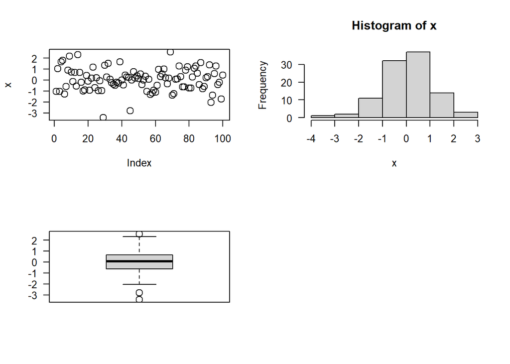

```r
x <- rnorm(100)
par(mfrow = c(2, 2))
plot(x, las = 1, cex = 1.5)
hist(x, las = 1, cex = 1.5)
boxplot(x, las = 1, cex = 1.5)
```

#### 1.2 To induce a linear relationship between x and a dependent variable y, generate the vector y using a linear transformation of the vector x:

```r
y1 <- 0 + 1 * x  ## A perfect linear association
y2 <- 0 + 1 * x + rnorm(length(x), mean = 0, sd = sqrt(1))  # Add a little N(0,1) noise (error)
```

#### 1.3 Compute, y3,y4,y5,y6

#### $y_{i} = \beta_{0} + \beta_{1}x_{i} + \epsilon_{i} ~ N(0,\sigma^{2})$

```r
y3 <- 0 + 1 * x + rnorm(length(x), mean = 0, sd = sqrt(3))
y4 <- 0 + 1 * x + rnorm(length(x), mean = 0, sd = sqrt(5))
y5 <- 0 + 1 * x + rnorm(length(x), mean = 0, sd = sqrt(7))
y6 <- 0 + 1 * x + rnorm(length(x), mean = 0, sd = sqrt(9))
```

#### 1.4 Generate scatterplots, r, and R2

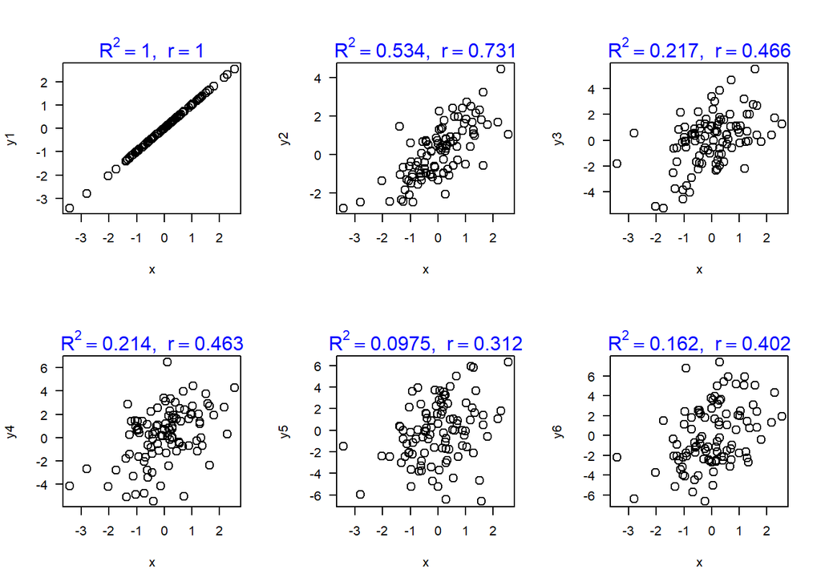

```r
vlist <- list(y1, y2, y3, y4, y5, y6)
par(mfrow = c(2, 3))
nv <- c(1, 2, 3, 4, 5, 6)
rv <- c(1, 2, 3, 4, 5, 6)
sdv <- c(sqrt(0), sqrt(1), sqrt(3), sqrt(5), sqrt(7), sqrt(9))
R2v <- c(1, 2, 3, 4, 5, 6)
i = 0
for (yi in vlist) {
    i <- i + 1
    rv[i] <- cor(x, yi)
    R2v[i] <- summary(lm(yi ~ x))$r.squared
    plot(x, yi, las = 1, cex = 1.5, ylab = paste("y", nv[i],
        sep = ""))
    mtext(bquote(paste(R^2 == .(R2v[i]), ", ", ~r == .(rv[i]))),
        col = "blue")
}
```

#### 1.5 Plot r and R2 versus standard deviation

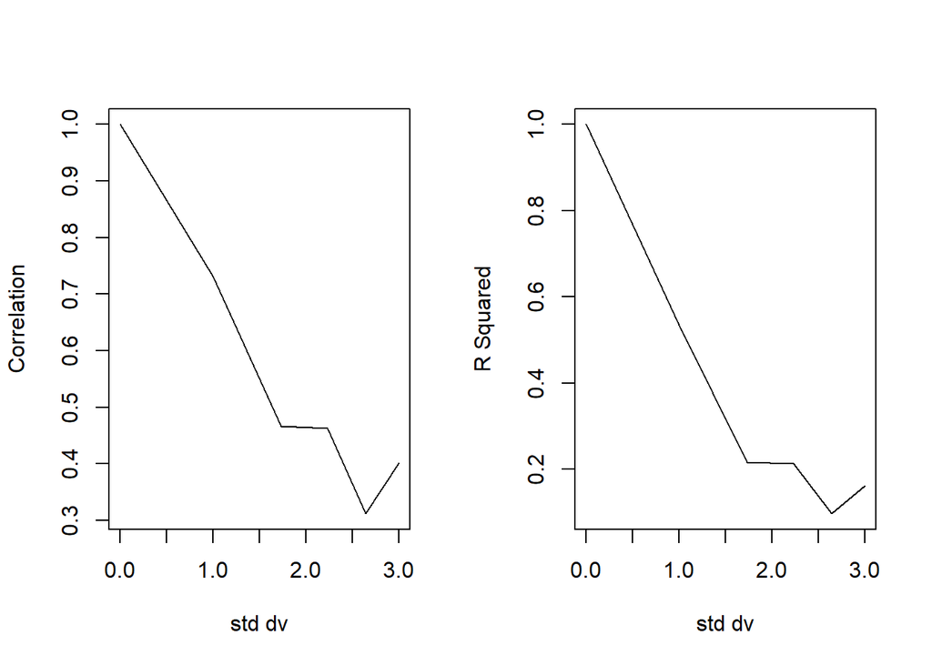

```r
par(mfrow = c(1, 2))
plot(sdv, rv, type = "l", xlab = "std dv", ylab = "Correlation")
plot(sdv, R2v, type = "l", xlab = "std dv", ylab = "R Squared")
```

#### Observation

- From above plots, we can say that as standard deviation of the noise increases, the coefficients of correlation and R-squared decreases.

### 2. Simple Linear Regression

#### 1. Write out the regression model that would explore the proposed relationship and state the model assumptions.

```r
gscore <- read.csv("GPA.csv")
regmodel <- lm(gscore$GPA ~ gscore$ACT)
modelsumm <- summary(regmodel)
names(regmodel)
```

```
##  [1] "coefficients"  "residuals"     "effects"       "rank"
##  [5] "fitted.values" "assign"        "qr"            "df.residual"
##  [9] "xlevels"       "call"          "terms"         "model"
```

```r
names(modelsumm)
```

```
##  [1] "call"          "terms"         "residuals"     "coefficients"
##  [5] "aliased"       "sigma"         "df"            "r.squared"
##  [9] "adj.r.squared" "fstatistic"    "cov.unscaled"
```

```r
modelsumm
```

```
##
## Call:
## lm(formula = gscore$GPA ~ gscore$ACT)
##
## Residuals:
##     Min      1Q  Median      3Q     Max
## -2.7400 -0.3383  0.0406  0.4406  1.2274
##
## Coefficients:
##             Estimate Std. Error t value Pr(>|t|)
## (Intercept)   2.1140     0.3209    6.59  1.3e-09 ***
## gscore$ACT    0.0388     0.0128    3.04   0.0029 **
## ---
## Signif. codes:  0 '***' 0.001 '**' 0.01 '*' 0.05 '.' 0.1 ' ' 1
##
## Residual standard error: 0.623 on 118 degrees of freedom
## Multiple R-squared:  0.0726, Adjusted R-squared:  0.0648
## F-statistic: 9.24 on 1 and 118 DF,  p-value: 0.00292
```

#### Assumptions

- Homoscedasticity
- Normality
- Correlation

#### 2. Testing Assumptions

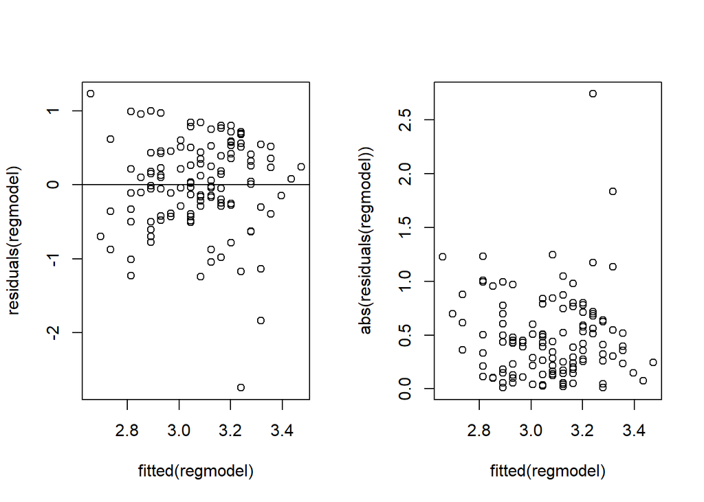

```r
# Homoscedasticity
par(mfrow = c(1, 2))
plot(fitted(regmodel), residuals(regmodel))
abline(h = 0)
plot(fitted(regmodel), abs(residuals(regmodel)))
```

```r
summary(lm(abs(residuals(regmodel)) ~ fitted(regmodel)))
```

```
##
## Call:
## lm(formula = abs(residuals(regmodel)) ~ fitted(regmodel))
##
## Residuals:
##    Min     1Q Median     3Q    Max
## -0.464 -0.292 -0.057  0.210  2.267
##
## Coefficients:
##                  Estimate Std. Error t value Pr(>|t|)
## (Intercept)       0.49554    0.64949    0.76     0.45
## fitted(regmodel) -0.00696    0.21095   -0.03     0.97
##
## Residual standard error: 0.4 on 118 degrees of freedom
## Multiple R-squared:  9.23e-06,   Adjusted R-squared:  -0.00847
## F-statistic: 0.00109 on 1 and 118 DF,  p-value: 0.974
```

```r
ncvTest(regmodel)
```

```
## Non-constant Variance Score Test
## Variance formula: ~ fitted.values
## Chisquare = 0.639, Df = 1, p = 0.4
```

```r
# Normality
qqnorm(residuals(regmodel), main = "QQ Plot")
qqline(residuals(regmodel))
# ggqqplot(residuals(regmodel))
shapiro.test(residuals(regmodel))
```

```
##
##  Shapiro-Wilk normality test
##
## data:  residuals(regmodel)
## W = 1, p-value = 3e-04
```

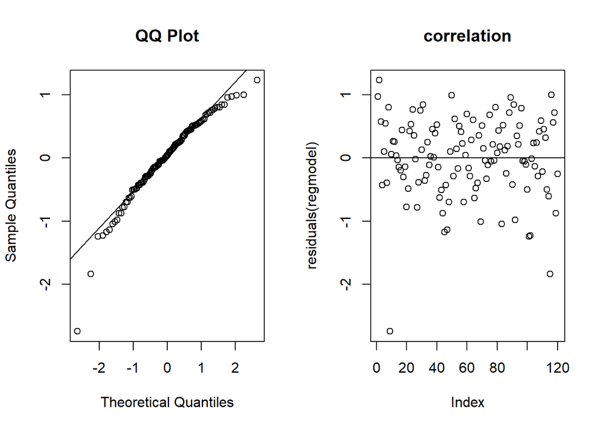

```r
# Correlation
plot(residuals(regmodel), main = "correlation")
abline(h = 0)
```

```r
# summary(lm(residuals(regmodel)[-1] ~
# -1+residuals(regmodel)[-541]))
dwtest(regmodel)
```

```
##
##  Durbin-Watson test
##
## data:  regmodel
## DW = 2, p-value = 0.2
## alternative hypothesis: true autocorrelation is greater than 0
```